# Covid Analysis

Trae Smith

2025-07-24

```r
global_covid_data<-readxl::read_xlsx("owid-covid-data.xlsx")
```

Since this shows the global covid data, we can compare different countries to each other. For the mini project, I will focus on Canada, United States, and Mexico.

For a general understanding of how Covid-19 affected these 3 countries, we can plot the increase across the months

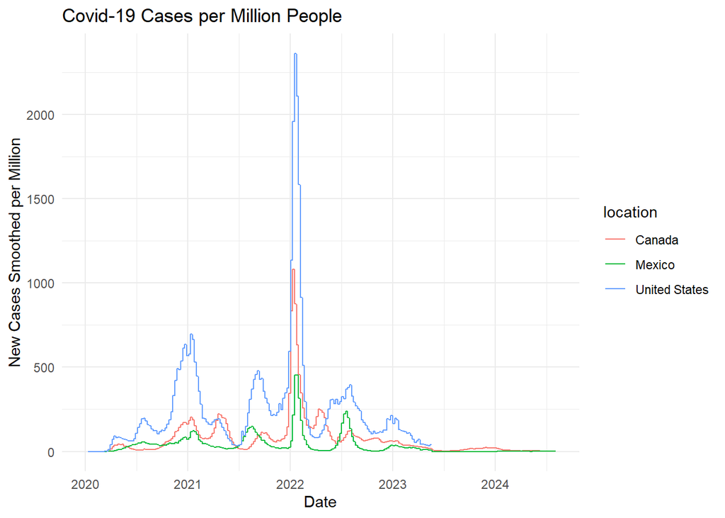

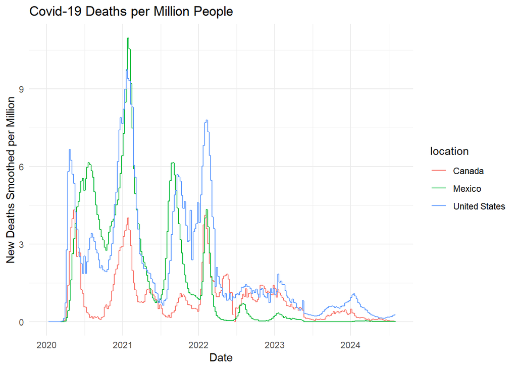

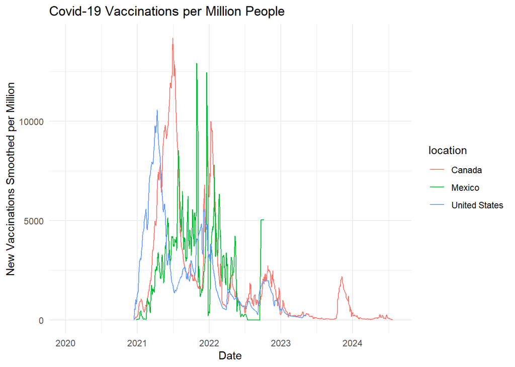

As we can see, the United States had the highest number of cases per million people, being about double of the countries afterward, Canada. Mexico have the smallest peak across the 3 countries. The peak in cases for all three countries occurred around Early 2022, which aligns with the global trend of Covid-19 cases. The deaths compared to each other is another story. Mexico have the largest amount of deaths at one point, which is surprising given that it had the lowest number of cases. The United States had the second highest number of deaths, while Canada had the lowest number of deaths. However, USA has consistently increased compared to Mexico, who only had a spike in deaths at one point and smaller ones 3 times. You can see that Canada had the highest number of vaccinations in the middle of 2021. Mexico followed with 2 quick peaks at the end of 2021 and USA having the lowest in the middle of 2021 as well.

To further analyze the impact of Covid-19, we can look at the trends for each countries across each month. Starting at the North, Canada.

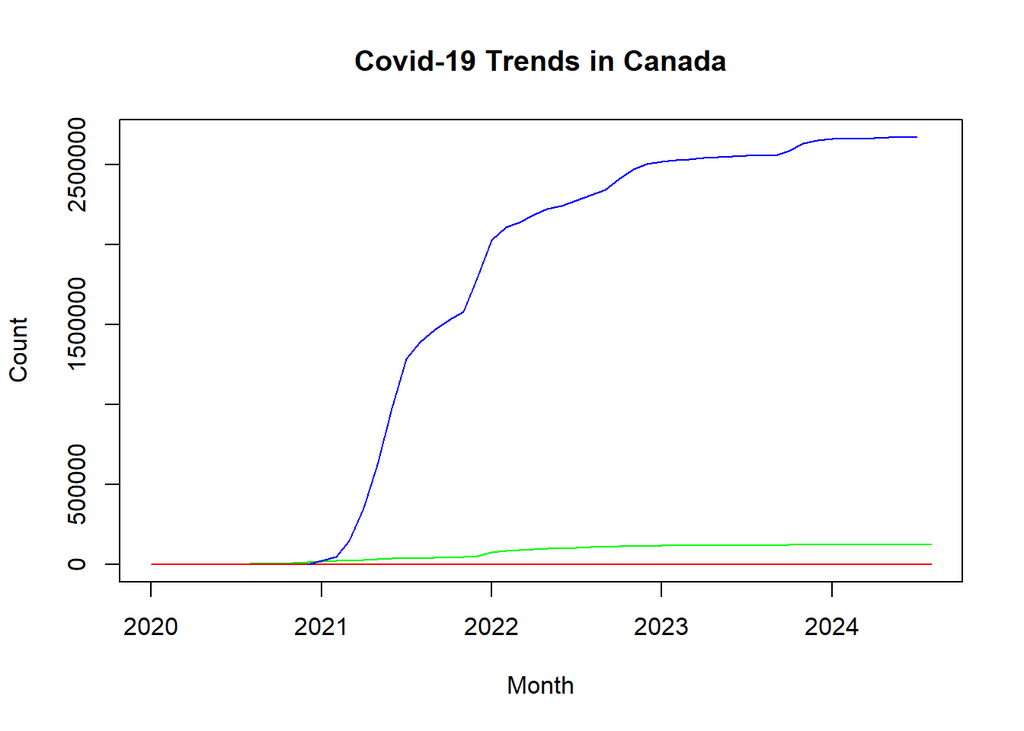

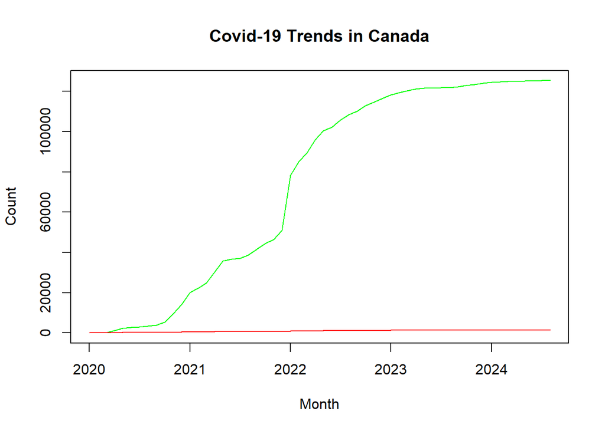

We can see the large amount of vaccinations that occurred in Canada (signified by blue), which shows that many people have taken it amidst the pandemic. Also, around early 2022, we can also see a small spike in cases.

Compared to both vaccinations and the number of cases, the deaths (red) are significantly lower, which shows that while many people have contracted the virus, the death rate is not as high.

Now for United States:

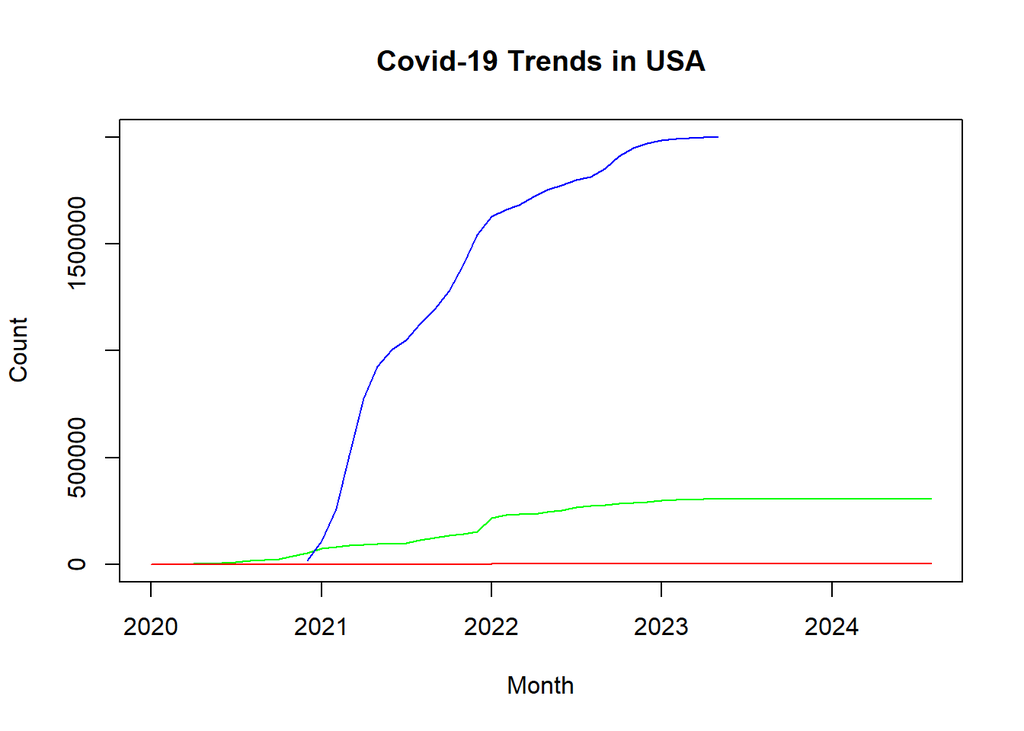

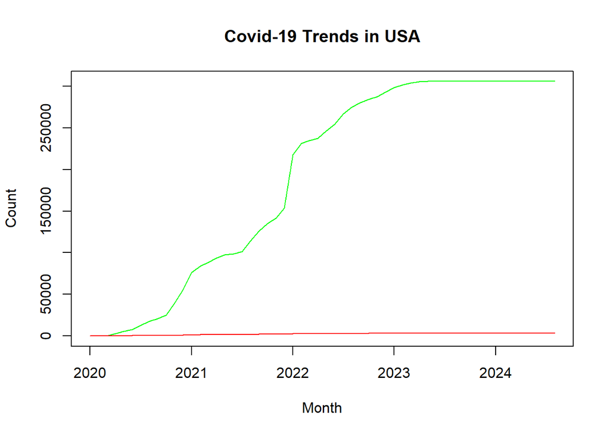

Compared to its neighbor to the north, the United States has a significantly higher number of cases and deaths. The vaccination rate is also lower than Canada, which shows that the country was not able to handle the pandemic as well as Canada. The peak in cases for the United States also occurred around early 2022, which aligns with the global trend of Covid-19 cases.

Finally, we can look at Mexico:

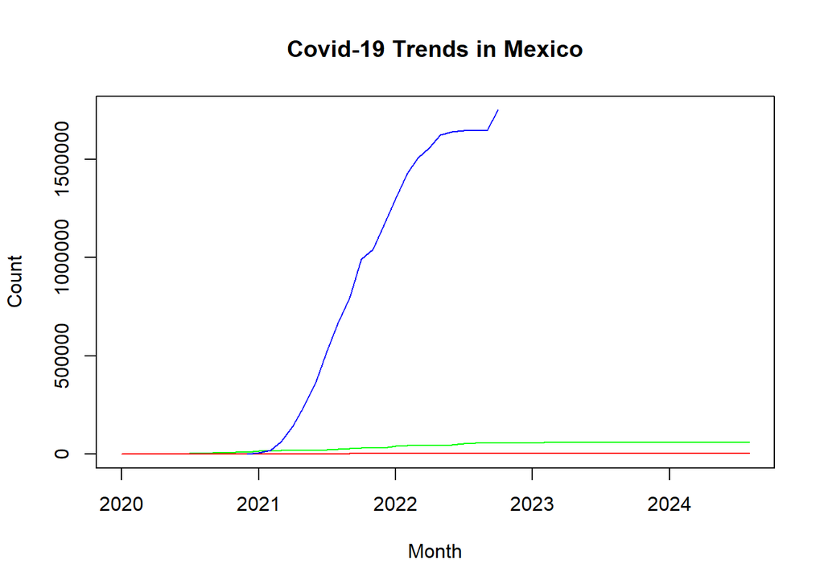

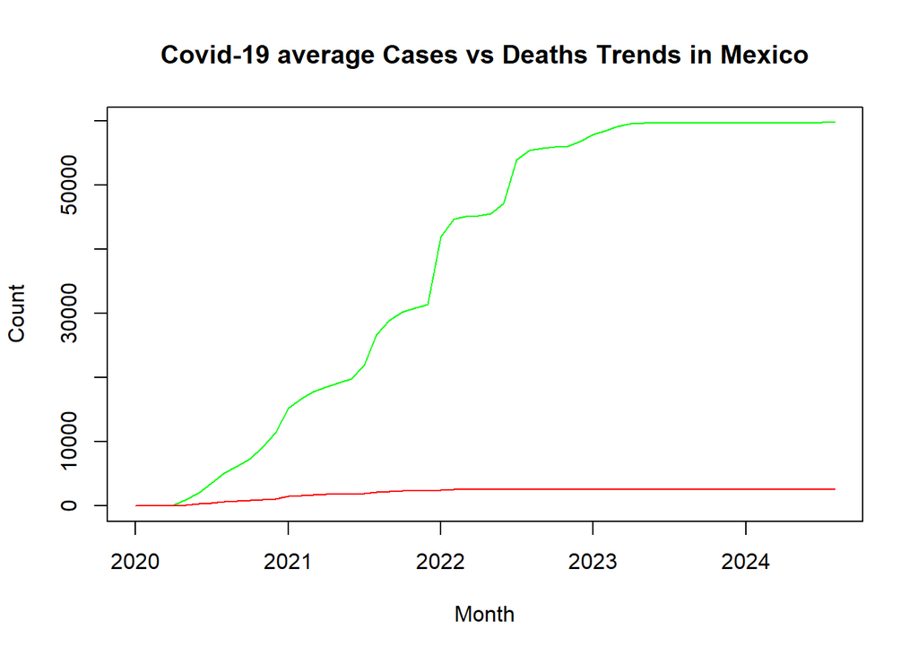